Presplit iteration

```r
#### 1. Load data

##### Load base training/test dataset and ensure proper class assignments
```

```r
#train
base.ps = read.csv("C:/Users/Joshua/Google Drive/MSBA/Capstone/Morton/Modeling/Presplit/presplit train.csv")

base.ps$Memid = as.factor(base.ps$Memid)
base.ps$Visits = as.numeric(base.ps$Visits)
base.ps$Rental = as.numeric(base.ps$Rental)
base.ps$Bday_party = as.numeric(base.ps$Bday_party)
base.ps$CnBio.Age = as.numeric(base.ps$CnBio.Age)
base.ps$CnMem.1.01.Consecutive.Years = as.numeric(base.ps$CnMem.1.01.Consecutive.Years)
base.ps = subset(base.ps, select=-c(Expiration.Date))

base.ps$CnMem.1.01.Standing = as.factor(base.ps$CnMem.1.01.Standing)
class(base.ps$CnMem.1.01.Standing)
```

```
## [1] "factor"
```

```r
#imp
imp.ps = read.csv("C:/Users/Joshua/Google Drive/MSBA/Capstone/Morton/Modeling/Presplit/presplit test.csv")

imp.ps$Memid = as.factor(imp.ps$Memid)
imp.ps$Visits = as.numeric(imp.ps$Visits)
imp.ps$Rental = as.numeric(imp.ps$Rental)
imp.ps$Bday_party = as.numeric(imp.ps$Bday_party)
imp.ps$CnBio.Age = as.numeric(imp.ps$CnBio.Age)
imp.ps$CnMem.1.01.Consecutive.Years = as.numeric(imp.ps$CnMem.1.01.Consecutive.Years)
imp.ps = subset(imp.ps, select=-c(Expiration.Date))

imp.ps$CnMem.1.01.Standing = as.factor(imp.ps$CnMem.1.01.Standing)
class(imp.ps$CnMem.1.01.Standing)
```

```
## [1] "factor"
```

#### 2. Dealing with missing values

##### Option 1: remove instances with missing values

```r
# train
base.ps.sansage = subset(base.ps, select = -c(Age.Group, CnBio.Age))
# Version 1 - excluding age variables, remove the few na instnaces in the Distance variable
base.ps.excludeAge = base.ps.sansage[complete.cases(base.ps.sansage),]
# version 2 - including age variables, remove all na instnaces (approx 50%)
base.ps.includeAge = base.ps[complete.cases(base.ps),]
# remove age and age group
imp.ps.sansage = subset(imp.ps, select = -c(Age.Group, CnBio.Age))

# imp
# Version 1 - excluding age variables, remove the few na instnaces in the Distance variable
imp.ps.excludeAge = imp.ps.sansage[complete.cases(imp.ps.sansage),]
# version 2 - including age variables, remove all na instnaces (approx 50%)
imp.ps.includeAge = imp.ps[complete.cases(imp.ps),]
```

##### remove Memid

```r
# train
base.ps.excludeAge = subset(base.ps.excludeAge, select=-c(Memid))
base.ps.includeAge = subset(base.ps.includeAge, select=-c(Memid))

# imp
imp.ps.excludeAge = subset(imp.ps.excludeAge, select=-c(Memid))
imp.ps.includeAge = subset(imp.ps.includeAge, select=-c(Memid))
```

> Accounting for missing values has resulted in the following data sets:
- Remove missing values from training set
- base.ps.excludeAge: excluding age variables and removing all na instances
- base.ps.includeAge: including age variables and removing all na instances
- Remove missing values from implementation set
- imp.ps.excludeAge: excluding age variables and removing all na instances
- imp.ps.includeAge: including age variables and removing all na instances

#### 4. Apply transformations (boxcox, center, scale, pca)

```r
# train
# first apply log transformations to numeric variables - only applied to distance as all other numeric variables contain a significant amount of zeros

base.ps.excludeAge$Distance.log = log(base.ps.excludeAge$Distance)
base.ps.includeAge$Distance.log = log(base.ps.includeAge$Distance)

numerics.age2 = c("Visits", "NetAmt", "Rental", "Bday_party", "Events", "CnBio.Age", "CnMem.1.01.Consecutive.Years", "Distance", "Distance.log")
numerics.noage2 = c("Visits", "NetAmt", "Rental", "Bday_party", "Events", "CnMem.1.01.Consecutive.Years", "Distance", "Distance.log")

# reassess for skewnesss
base.ps.excludeAge.N2 = base.ps.excludeAge[,numerics.noage2]
base.ps.includeAge.N2 = base.ps.includeAge[,numerics.age2]

# ignores categorical variables and only applies the preProcess function to numeric varaibles
# essentially replace preProcess with ppWrapper
# saves results as dataframe
ppWrapper = function( x, excludeClasses=c("factor"), ... ) {
    whichToExclude <- sapply( x, function(y) any(sapply(excludeClasses, function(excludeClass) is(y,excludeClass) )) )
    processedMat <- predict( preProcess( x[!whichToExclude], ...), newdata=x[!whichToExclude] )
    x[!whichToExclude] <- processedMat
    x
}

library(caret)
base.ps.excludeAge.Proc = ppWrapper(base.ps.excludeAge, method = c("BoxCox", "center", "scale","pca"))
base.ps.includeAge.Proc = ppWrapper(base.ps.includeAge, method = c("BoxCox", "center", "scale","pca"))

# remove distance since distance.log created
base.ps.excludeAge.Proc2 = subset(base.ps.excludeAge.Proc, select=-c(Distance))
base.ps.includeAge.Proc2 = subset(base.ps.includeAge.Proc, select=-c(Distance))

#imp

# first apply log transformations to numeric variables - only applied to distance as all other numeric variables contain a significant amount of zeros

imp.ps.excludeAge$Distance.log = log(imp.ps.excludeAge$Distance)
imp.ps.includeAge$Distance.log = log(imp.ps.includeAge$Distance)

# reassess for skewnesss
imp.ps.excludeAge.N2 = imp.ps.excludeAge[,numerics.noage2]
imp.ps.includeAge.N2 = imp.ps.includeAge[,numerics.age2]

imp.ps.excludeAge.Proc = ppWrapper(imp.ps.excludeAge, method = c("BoxCox", "center", "scale","pca"))
imp.ps.includeAge.Proc = ppWrapper(imp.ps.includeAge, method = c("BoxCox", "center", "scale","pca"))

# remove distance since distance.log created
imp.ps.excludeAge.Proc2 = subset(imp.ps.excludeAge.Proc, select=-c(Distance))
imp.ps.includeAge.Proc2 = subset(imp.ps.includeAge.Proc, select=-c(Distance))
```

> Transformations lowered skewness values. Created the following files with transformed numeric variables and original nominal variables: - base.ps.excludeAge.Proc2  
> - base.ps.includeAge.Proc2

> Transformations lowered skewness values. Created the following files with transformed numeric variables and original nominal variables: - imp.ps.excludeAge.Proc2  
> - imp.ps.includeAge.Proc2

#### 3. Convert all categorical/nominal variables to numeric Dummy variables

```r
# train

base.ps.excludeAge.Proc2$CnMem.1.01.Standing = as.numeric(base.ps.excludeAge.Proc2$CnMem.1.01.Standing) #convert target to numeric to prevent dummification
a.ps = dummyVars("~ .", data=base.ps.excludeAge.Proc2, levelsOny=TRUE)
base.ps.excludeAge.Proc.dummy = data.frame(predict(a.ps, newdata = base.ps.excludeAge.Proc2))
base.ps.excludeAge.Proc.dummy$CnMem.1.01.Standing = as.factor(base.ps.excludeAge.Proc.dummy$CnMem.1.01.Standing)# convert back to factor
base.ps.excludeAge.Proc.dummy$CnMem.1.01.Standing = as.factor(ifelse(base.ps.excludeAge.Proc.dummy$CnMem.1.01.Standing == "1", "0", "1"))

base.ps.includeAge.Proc2$CnMem.1.01.Standing = as.numeric(base.ps.includeAge.Proc2$CnMem.1.01.Standing)
b.ps = dummyVars("~ .", data=base.ps.includeAge.Proc2, levelsOny=TRUE)
base.ps.includeAge.Proc.dummy = data.frame(predict(b.ps, newdata = base.ps.includeAge.Proc2))
base.ps.includeAge.Proc.dummy$CnMem.1.01.Standing = as.factor(base.ps.includeAge.Proc.dummy$CnMem.1.01.Standing)
base.ps.includeAge.Proc.dummy$CnMem.1.01.Standing = as.factor(ifelse(base.ps.includeAge.Proc.dummy$CnMem.1.01.Standing == "1", "0", "1"))
#imp

imp.ps.excludeAge.Proc2$CnMem.1.01.Standing = as.numeric(imp.ps.excludeAge.Proc2$CnMem.1.01.Standing) #convert target to numeric to prevent dummification

a.ps.i = dummyVars("~ .", data=imp.ps.excludeAge.Proc2, levelsOny=TRUE)
imp.ps.excludeAge.Proc.dummy = data.frame(predict(a.ps.i, newdata = imp.ps.excludeAge.Proc2))
imp.ps.excludeAge.Proc.dummy$CnMem.1.01.Standing = as.factor(imp.ps.excludeAge.Proc.dummy$CnMem.1.01.Standing)# convert back to factor
imp.ps.excludeAge.Proc.dummy$CnMem.1.01.Standing = as.factor(ifelse(imp.ps.excludeAge.Proc.dummy$CnMem.1.01.Standing == "1", "0", "1"))

imp.ps.includeAge.Proc2$CnMem.1.01.Standing = as.numeric(imp.ps.includeAge.Proc2$CnMem.1.01.Standing)

b.ps.i = dummyVars("~ .", data=imp.ps.includeAge.Proc2, levelsOny=TRUE)
imp.ps.includeAge.Proc.dummy = data.frame(predict(b.ps.i, newdata = imp.ps.includeAge.Proc2))
imp.ps.includeAge.Proc.dummy$CnMem.1.01.Standing = as.factor(imp.ps.includeAge.Proc.dummy$CnMem.1.01.Standing)
imp.ps.includeAge.Proc.dummy$CnMem.1.01.Standing = as.factor(ifelse(imp.ps.includeAge.Proc.dummy$CnMem.1.01.Standing == "1", "0", "1"))

# rerun to restore pre-dummy sets
base.ps.excludeAge.Proc2 = subset(base.ps.excludeAge.Proc, select=-c(Distance))
base.ps.includeAge.Proc2 = subset(base.ps.includeAge.Proc, select=-c(Distance))
imp.ps.excludeAge.Proc2 = subset(imp.ps.excludeAge.Proc, select=-c(Distance))
imp.ps.includeAge.Proc2 = subset(imp.ps.includeAge.Proc, select=-c(Distance))
```

> Created the following files with transformed numeric variables and dummified nominal variables: - base.ps.excludeAge.Proc.dummy  
> - base.ps.includeAge.Proc.dummy

> Created the following files with transformed numeric variables and dummified nominal variables: - imp.ps.excludeAge.Proc.dummy  
> - imp.ps.includeAge.Proc.dummy

#### 4. Train and eval model on preprocessed data sets

```r
library(pROC)
library(RWeka)
library(randomForest)
library(C50)


# remove membership types from training set that are not in imp data set
str(base.ps.excludeAge.Proc.dummy)
```

```
## 'data.frame':    11070 obs. of  31 variables:
##  $ CnMem.1.01.Standing                                 : Factor w/ 2 levels "0","1": 2 2 2 2 2 2 2 2 2 2 ...
##  $ Visits                                              : num  0.231 -0.775 -0.787 -0.387 -0.478 ...
##  $ NetAmt                                              : num  1.413 -1.6 -1.636 -0.439 -0.711 ...
##  $ Rental                                              : num  -1.426 0.147 0.165 -0.46 -0.317 ...
##  $ Bday_party                                          : num  -0.49671 -0.01304 -0.00725 -0.19987 -0.15604 ...
##  $ Events                                              : num  0.44889 0.01029 0.00502 0.1799 0.14012 ...
##  $ CnAttrCat.5.01.Description.                         : num  1 1 1 1 1 1 1 1 1 1 ...
##  $ CnAttrCat.5.01.Description.Donor                    : num  0 0 0 0 0 0 0 0 0 0 ...
##  $ CnBio.Constit.Code.Employee                         : num  0 0 0 0 0 0 0 0 0 0 ...
##  $ CnBio.Constit.Code.Individuals                      : num  1 1 1 1 1 1 1 1 1 1 ...
##  $ CnBio.Constit.Code.Trustee                          : num  0 0 0 0 0 0 0 0 0 0 ...
##  $ CnBio.Constit.Code.Volunteers                       : num  0 0 0 0 0 0 0 0 0 0 ...
##  $ CnMem.1.01.Consecutive.Years                        : num  0.222 0.202 0.201 0.209 0.207 ...
##  $ CnMem.1.01.Cur.Category.description.2.YR.Family.Plus: num  0 0 0 0 0 0 0 0 0 0 ...
```

[output cut: 17 more lines]

```r
str(imp.ps.excludeAge.Proc.dummy)
```

[output not shown]

```r
base.ps.excludeAge.Proc.dummy.rem = subset(base.ps.excludeAge.Proc.dummy, select = -c(CnMem.1.01.Cur.Category.description.2.YR.Family.Plus, CnMem.1.01.Cur.Category.description.Ginkgo.Circle, CnMem.1.01.Cur.Category.description.Retiree, CnMem.1.01.Cur.Category.description.Trustee,  CnBio.Constit.Code.Trustee ))

#run j48
J48.TRN.BpEPD = J48(CnMem.1.01.Standing ~ ., base.ps.excludeAge.Proc.dummy.rem)
J48.TST.BpEPD = predict(J48.TRN.BpEPD, imp.ps.excludeAge.Proc.dummy, type="prob")

imp.ps.excludeAge.Proc.dummy$J48prob = J48.TST.BpEPD[,"1"]
J48.BpEPD.ROC = roc(response = imp.ps.excludeAge.Proc.dummy$CnMem.1.01.Standing, predictor = imp.ps.excludeAge.Proc.dummy$J48prob, levels = rev(levels(imp.ps.excludeAge.Proc.dummy$CnMem.1.01.Standing)))

auc(J48.BpEPD.ROC)
```

```
## Area under the curve: 0.587
```

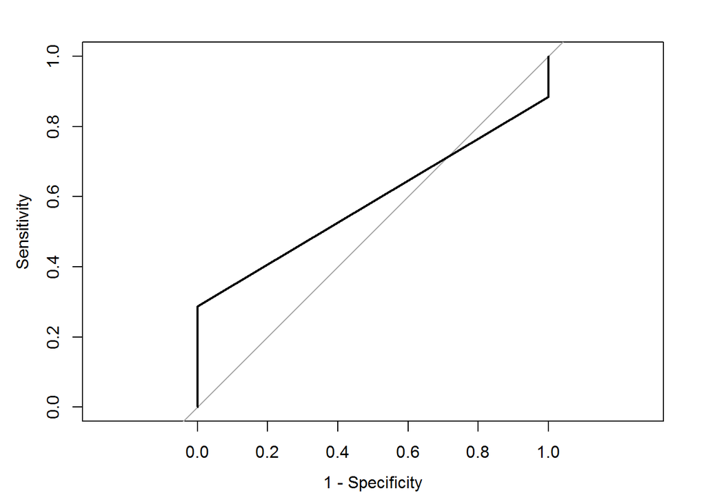

```
##
## Call:
## roc.default(response = imp.ps.excludeAge.Proc.dummy$CnMem.1.01.Standing,     predictor = imp.ps.excludeAge.Proc.dummy$J48prob, levels = rev(levels(imp.ps.excludeAge.Proc.dummy$CnMem.1.01.Standing)))
##
## Data: imp.ps.excludeAge.Proc.dummy$J48prob in 2410 controls (imp.ps.excludeAge.Proc.dummy$CnMem.1.01.Standing 1) < 5402 cases (imp.ps.excludeAge.Proc.dummy$CnMem.1.01.Standing 0).
## Area under the curve: 0.587
```

```r
plot(J48.BpEPD.ROC, legacy.axes = TRUE)
```

```r
#run LMT
LMT.TRN.BpEPD = LMT(CnMem.1.01.Standing ~ ., base.ps.excludeAge.Proc.dummy.rem)
LMT.TST.BpEPD = predict(LMT.TRN.BpEPD, imp.ps.excludeAge.Proc.dummy, type="prob")

imp.ps.excludeAge.Proc.dummy$LMTprob = LMT.TST.BpEPD[,"1"]
LMT.BpEPD.ROC = roc(response = imp.ps.excludeAge.Proc.dummy$CnMem.1.01.Standing, predictor = imp.ps.excludeAge.Proc.dummy$LMTprob, levels = rev(levels(imp.ps.excludeAge.Proc.dummy$CnMem.1.01.Standing)))

auc(LMT.BpEPD.ROC)
```

```
## Area under the curve: 0.737
```

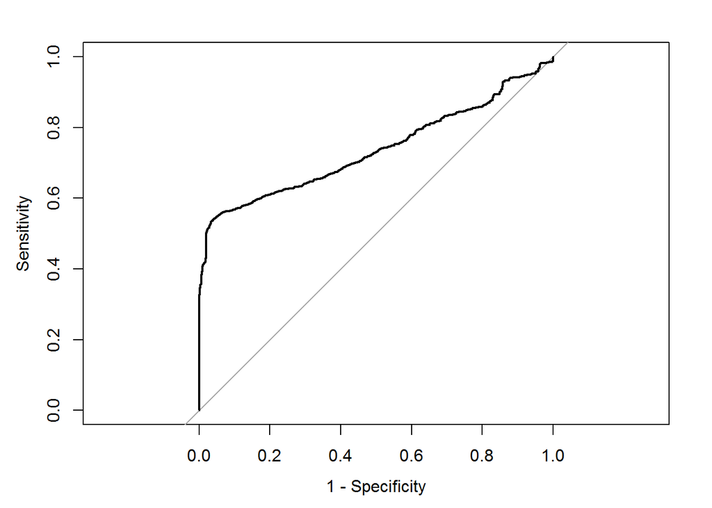

```
##
## Call:
## roc.default(response = imp.ps.excludeAge.Proc.dummy$CnMem.1.01.Standing,     predictor = imp.ps.excludeAge.Proc.dummy$LMTprob, levels = rev(levels(imp.ps.excludeAge.Proc.dummy$CnMem.1.01.Standing)))
##
## Data: imp.ps.excludeAge.Proc.dummy$LMTprob in 2410 controls (imp.ps.excludeAge.Proc.dummy$CnMem.1.01.Standing 1) < 5402 cases (imp.ps.excludeAge.Proc.dummy$CnMem.1.01.Standing 0).
## Area under the curve: 0.737
```

```r
plot(LMT.BpEPD.ROC, legacy.axes = TRUE)
```

```r
#run randomForest
RF.TRN.BpEPD = randomForest(CnMem.1.01.Standing ~ ., base.ps.excludeAge.Proc.dummy.rem)
RF.TST.BpEPD = predict(RF.TRN.BpEPD, imp.ps.excludeAge.Proc.dummy, type="prob")

imp.ps.excludeAge.Proc.dummy$RFprob = RF.TST.BpEPD[,"1"]
RF.BpEPD.ROC = roc(response = imp.ps.excludeAge.Proc.dummy$CnMem.1.01.Standing, predictor = imp.ps.excludeAge.Proc.dummy$RFprob, levels = rev(levels(imp.ps.excludeAge.Proc.dummy$CnMem.1.01.Standing)))

auc(RF.BpEPD.ROC)
```

```
## Area under the curve: 0.705
```

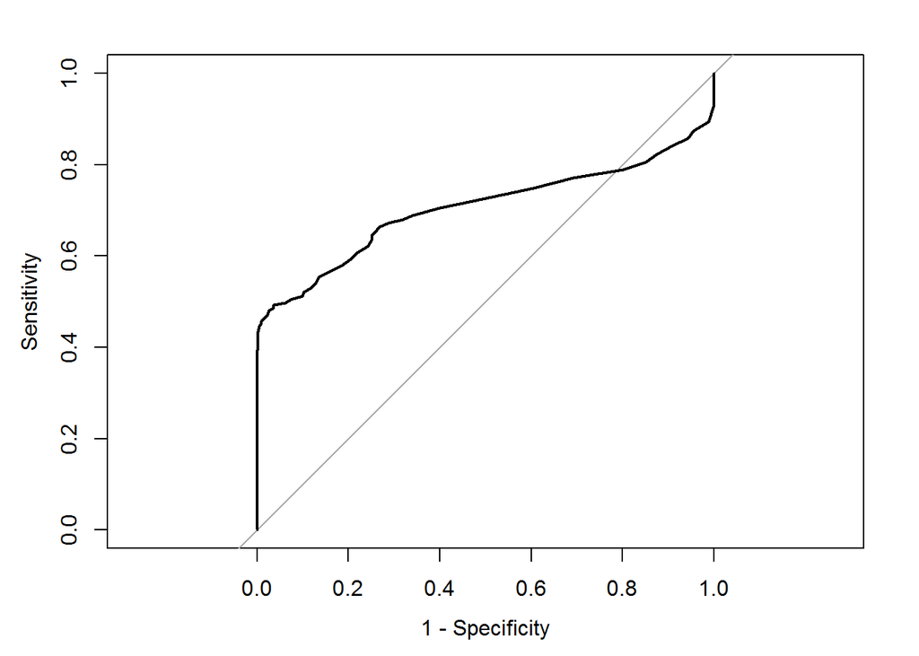

```
##
## Call:
## roc.default(response = imp.ps.excludeAge.Proc.dummy$CnMem.1.01.Standing,     predictor = imp.ps.excludeAge.Proc.dummy$RFprob, levels = rev(levels(imp.ps.excludeAge.Proc.dummy$CnMem.1.01.Standing)))
##
## Data: imp.ps.excludeAge.Proc.dummy$RFprob in 2410 controls (imp.ps.excludeAge.Proc.dummy$CnMem.1.01.Standing 1) < 5402 cases (imp.ps.excludeAge.Proc.dummy$CnMem.1.01.Standing 0).
## Area under the curve: 0.705
```

```r
plot(RF.BpEPD.ROC, legacy.axes = TRUE)
```

```r
#run C5.0
C5.0.TRN.BpEPD = C5.0(CnMem.1.01.Standing ~ ., base.ps.excludeAge.Proc.dummy.rem)
C5.0.TST.BpEPD = predict(C5.0.TRN.BpEPD, imp.ps.excludeAge.Proc.dummy, type="prob")

imp.ps.excludeAge.Proc.dummy$C5.0prob = C5.0.TST.BpEPD[,"1"]
C5.0.BpEPD.ROC = roc(response = imp.ps.excludeAge.Proc.dummy$CnMem.1.01.Standing, predictor = imp.ps.excludeAge.Proc.dummy$C5.0prob, levels = rev(levels(imp.ps.excludeAge.Proc.dummy$CnMem.1.01.Standing)))

auc(C5.0.BpEPD.ROC)
```

```
## Area under the curve: 0.615
```

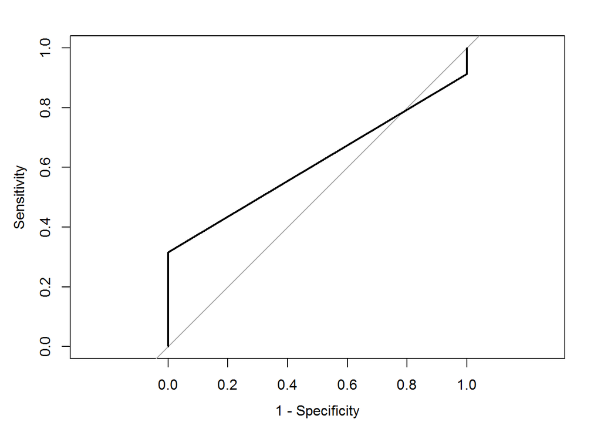

```
##
## Call:
## roc.default(response = imp.ps.excludeAge.Proc.dummy$CnMem.1.01.Standing,     predictor = imp.ps.excludeAge.Proc.dummy$C5.0prob, levels = rev(levels(imp.ps.excludeAge.Proc.dummy$CnMem.1.01.Standing)))
##
## Data: imp.ps.excludeAge.Proc.dummy$C5.0prob in 2410 controls (imp.ps.excludeAge.Proc.dummy$CnMem.1.01.Standing 1) < 5402 cases (imp.ps.excludeAge.Proc.dummy$CnMem.1.01.Standing 0).
## Area under the curve: 0.615
```

```r
plot(C5.0.BpEPD.ROC, legacy.axes = TRUE)
```

#### 5. Train and eval model on un-preprocessed (except missing values) data sets

```r
# align nominal predictor levels (i.e. remove levels/instances from training set not in test set)

str(base.ps.excludeAge)
```

```
## 'data.frame':    11070 obs. of  13 variables:
##  $ CnMem.1.01.Standing                : Factor w/ 2 levels "0","1": 2 2 2 2 2 2 2 2 2 2 ...
##  $ Visits                             : num  0 0 0 0 0 0 0 0 0 0 ...
##  $ NetAmt                             : num  0 0 0 0 0 0 0 0 0 0 ...
##  $ Rental                             : num  0 0 0 0 0 0 0 0 0 0 ...
##  $ Bday_party                         : num  0 0 0 0 0 0 0 0 0 0 ...
##  $ Events                             : int  0 0 0 0 0 0 0 0 0 0 ...
##  $ CnAttrCat.5.01.Description         : Factor w/ 2 levels "","Donor": 1 1 1 1 1 1 1 1 1 1 ...
##  $ CnBio.Constit.Code                 : Factor w/ 4 levels "Employee","Individuals",..: 2 2 2 2 2 2 2 2 2 2 ...
##  $ CnMem.1.01.Consecutive.Years       : num  0 0 0 0 0 0 0 0 0 0 ...
##  $ CnMem.1.01.Cur.Category.description: Factor w/ 16 levels "2 YR Family Plus",..: 10 9 3 11 11 10 12 11 9 4 ...
##  $ Distance                           : num  2.45 21.68 22.33 8.68 10.68 ...
##  $ donations                          : int  0 0 0 0 0 0 0 0 0 0 ...
##  $ Distance.log                       : num  0.898 3.077 3.106 2.16 2.369 ...
```

```r
str(imp.ps.excludeAge)
```

```
## 'data.frame':    7812 obs. of  13 variables:
##  $ CnMem.1.01.Standing                : Factor w/ 2 levels "0","1": 2 1 2 1 1 2 1 1 2 1 ...
##  $ Visits                             : num  8 1 0 0 2 0 6 4 0 7 ...
##  $ NetAmt                             : num  0 0 0 0 0 0 5 0 0 0 ...
##  $ Rental                             : num  0 0 0 0 0 0 0 0 0 0 ...
##  $ Bday_party                         : num  0 0 0 0 0 0 0 0 0 0 ...
##  $ Events                             : int  0 0 0 0 0 0 0 0 0 0 ...
##  $ CnAttrCat.5.01.Description         : Factor w/ 2 levels "","Donor": 2 2 1 1 1 1 1 1 1 1 ...
##  $ CnBio.Constit.Code                 : Factor w/ 3 levels "Employee","Individuals",..: 2 2 2 2 2 2 2 2 2 2 ...
##  $ CnMem.1.01.Consecutive.Years       : num  0 7 0 4 9 0 9 9 0 1 ...
##  $ CnMem.1.01.Cur.Category.description: Factor w/ 12 levels "2 YR Morton 1",..: 3 9 8 3 9 7 2 9 7 10 ...
##  $ Distance                           : num  4.78 10.61 11.26 2.6 10.68 ...
##  $ donations                          : int  0 0 0 0 0 0 0 0 0 0 ...
##  $ Distance.log                       : num  1.563 2.362 2.422 0.957 2.369 ...
```

```r
# CnBio.Constit.Code
levels(imp.ps.excludeAge$CnBio.Constit.Code)
```

```
## [1] "Employee"    "Individuals" "Volunteers"
```

```r
levels(base.ps.excludeAge$CnBio.Constit.Code) # remove Trustee
```

```
## [1] "Employee"    "Individuals" "Trustee"     "Volunteers"
```

```r
levels(base.ps.excludeAge$CnMem.1.01.Cur.Category.description)
```

```
##  [1] "2 YR Family Plus" "2 YR Morton 1"    "2 YR Morton 2"
##  [4] "2 YR Morton 4"    "2 YR Morton 6"    "Elm Circle"
##  [7] "Ginkgo Circle"    "Hawthorn Circle"  "Morton 1"
## [10] "Morton 2"         "Morton 4"         "Morton 6"
## [13] "Oak Circle"       "Partner"          "Retiree"
## [16] "Trustee"
```

```r
levels(imp.ps.excludeAge$CnMem.1.01.Cur.Category.description) # remove 2 YR Family Plus, Ginkgo Circle, Retiree, Trustee
```

```
##  [1] "2 YR Morton 1"   "2 YR Morton 2"   "2 YR Morton 4"
##  [4] "2 YR Morton 6"   "Elm Circle"      "Hawthorn Circle"
##  [7] "Morton 1"        "Morton 2"        "Morton 4"
## [10] "Morton 6"        "Oak Circle"      "Partner"
```

```r
base.ps.excludeAge.rem = base.ps.excludeAge[!(base.ps.excludeAge$CnBio.Constit.Code %in% c("Trustee") | base.ps.excludeAge$CnMem.1.01.Cur.Category.description %in% c("2 YR Family Plus", "Ginkgo Circle", "Retiree", "Trustee")),]

# excludeage dataset
# j48
J48.TRN.BpE = J48(CnMem.1.01.Standing ~ ., base.ps.excludeAge.rem) # train on test set
J48.TST.BpE = predict(J48.TRN.BpE, imp.ps.excludeAge, type="prob") # apply model on holdout set to get pred class and class probs

J48prob = J48.TST.BpE[,"1"] #grab the positive class, i.e. 1/churn
J48.BpE.ROC = roc(response = imp.ps.excludeAge$CnMem.1.01.Standing, predictor = J48prob)
confusionMatrix(data = J48prob, reference = imp.ps.excludeAge$CnMem.1.01.Standing, positive="1")
```

```
## Confusion Matrix and Statistics
##
##           Reference
## Prediction    0    1
##          0 5402    0
##          1    0 2410
##
##                Accuracy : 1
##                  95% CI : (1, 1)
##     No Information Rate : 0.692
##     P-Value [Acc > NIR] : <2e-16
##
##                   Kappa : 1
##  Mcnemar's Test P-Value : NA
##
##             Sensitivity : 1.000
##             Specificity : 1.000
##          Pos Pred Value : 1.000
##          Neg Pred Value : 1.000
##              Prevalence : 0.308
##          Detection Rate : 0.308
##    Detection Prevalence : 0.308
##       Balanced Accuracy : 1.000
##
##        'Positive' Class : 1
##
```

```r
auc(J48.BpE.ROC)
```

```
## Area under the curve: 1
```

```r
plot(J48.BpE.ROC, legacy.axes = TRUE)
```

[output not shown]

```
##
## Call:
## roc.default(response = imp.ps.excludeAge$CnMem.1.01.Standing,     predictor = J48prob)
##
## Data: J48prob in 5402 controls (imp.ps.excludeAge$CnMem.1.01.Standing 0) < 2410 cases (imp.ps.excludeAge$CnMem.1.01.Standing 1).
## Area under the curve: 1
```

```r
#j48 - weka verification
BpE.eval_J48 = evaluate_Weka_classifier(J48.TRN.BpE, imp.ps.excludeAge, class=TRUE)
BpE.eval_J48
```

```
##
## === Summary ===
##
## Correctly Classified Instances        7812              100      %
## Incorrectly Classified Instances         0                0      %
## Kappa statistic                          1
## Mean absolute error                      0
## Root mean squared error                  0
## Relative absolute error                  0      %
## Root relative squared error              0      %
## Coverage of cases (0.95 level)         100      %
## Mean rel. region size (0.95 level)      50      %
## Total Number of Instances             7812
##
## === Detailed Accuracy By Class ===
##
##                  TP Rate  FP Rate  Precision  Recall   F-Measure  MCC      ROC Area  PRC Area  Class
##                  1.000    0.000    1.000      1.000    1.000      1.000    1.000     1.000     0
##                  1.000    0.000    1.000      1.000    1.000      1.000    1.000     1.000     1
## Weighted Avg.    1.000    0.000    1.000      1.000    1.000      1.000    1.000     1.000
##
## === Confusion Matrix ===
##
##     a    b   <-- classified as
##  5402    0 |    a = 0
##     0 2410 |    b = 1
```

```r
# includeage dataset
# j48
J48.TRN.BpI = J48(CnMem.1.01.Standing ~ ., base.ps.includeAge) # train on test set
J48.TST.BpI = predict(J48.TRN.BpI, imp.ps.includeAge, type="prob") # apply model on holdout set

J48prob.I = J48.TST.BpI[,"1"]
J48.BpI.ROC = roc(response = imp.ps.includeAge$CnMem.1.01.Standing, predictor = J48prob.I)
confusionMatrix(data = J48prob.I, reference = imp.ps.includeAge$CnMem.1.01.Standing, positive="1")
```

```
## Confusion Matrix and Statistics
##
##           Reference
## Prediction    0    1
##          0 2924    0
##          1    0 1125
##
##                Accuracy : 1
##                  95% CI : (0.999, 1)
##     No Information Rate : 0.722
##     P-Value [Acc > NIR] : <2e-16
##
##                   Kappa : 1
##  Mcnemar's Test P-Value : NA
##
##             Sensitivity : 1.000
##             Specificity : 1.000
##          Pos Pred Value : 1.000
##          Neg Pred Value : 1.000
##              Prevalence : 0.278
##          Detection Rate : 0.278
##    Detection Prevalence : 0.278
##       Balanced Accuracy : 1.000
##
##        'Positive' Class : 1
##
```

```r
auc(J48.BpI.ROC)
```

```
## Area under the curve: 1
```

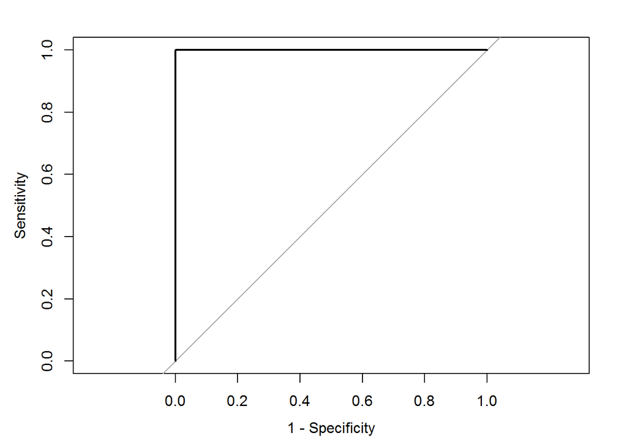

```
##
## Call:
## roc.default(response = imp.ps.includeAge$CnMem.1.01.Standing,     predictor = J48prob.I)
##
## Data: J48prob.I in 2924 controls (imp.ps.includeAge$CnMem.1.01.Standing 0) < 1125 cases (imp.ps.includeAge$CnMem.1.01.Standing 1).
## Area under the curve: 1
```

```r
plot(J48.BpI.ROC, legacy.axes = TRUE)
```

```r
#j48 - weka verification
BpI.eval_J48 = evaluate_Weka_classifier(J48.TRN.BpI, imp.ps.includeAge, class=TRUE)
BpI.eval_J48
```

```
##
## === Summary ===
##
## Correctly Classified Instances        4049              100      %
## Incorrectly Classified Instances         0                0      %
## Kappa statistic                          1
## Mean absolute error                      0
## Root mean squared error                  0
## Relative absolute error                  0      %
## Root relative squared error              0      %
## Coverage of cases (0.95 level)         100      %
## Mean rel. region size (0.95 level)      50      %
## Total Number of Instances             4049
##
## === Detailed Accuracy By Class ===
##
##                  TP Rate  FP Rate  Precision  Recall   F-Measure  MCC      ROC Area  PRC Area  Class
##                  1.000    0.000    1.000      1.000    1.000      1.000    1.000     1.000     0
##                  1.000    0.000    1.000      1.000    1.000      1.000    1.000     1.000     1
## Weighted Avg.    1.000    0.000    1.000      1.000    1.000      1.000    1.000     1.000
##
## === Confusion Matrix ===
##
##     a    b   <-- classified as
##  2924    0 |    a = 0
##     0 1125 |    b = 1
```